# Projekt: Herzrhythmusstoerungen Cluster- und Hauptkomponenten Analyse

Master of Disaster David PPPPPPham

# 1 Einleitung

Die folgende Untersuchung bezieht sich auf den Arrhythmia Datensatz aus dem UCI Machine Learning Repository. Ziel ist es eine Cluster- und Hauptkomponenten Analyse durchzufuehren und zu untersuchen ob die Ergebnisse mit den wahren Klassifizierungen uebereinstimmen.

Der Datensatz enthaelt die Ergebnisse eines Elektrokardiogramm von 452 Patienten mit jeweils 279 Attributen von denen 206 linear und 73 nominal sind. Darunter klassische Daten wie Alter, Gewicht und Koerpergroesse, aber hauptsaechlich handelt es sich hierbei um die sensorischen Daten der 12 Kanaele des EKG’s. Desweiteren beinhaltet der Datensatz die wahre Herzrythmusklassifizierung des Patienten die wir zur Wertung unserer eigenen Analyse heranziehen werden.

# 2 Vorbereitung

```r
require("psych")
require("AER")
require("mlbench")
require("cluster")
require("zoo")
require("plyr")
require("factoextra")
require("dendextend")
require("matrixStats") ## for rowSums, rowMeans....
require("factoextra")


farben <- c("#8DD3C7","#FFFFB3","#BEBADA","#FB8072","#80B1D3","#FDB462","#B3DE69","#FCCDE5","#D9D9D9","#BC80BD","#B0E2FF","#EE799F","#CCEBC5")

##  Daten einlesen ##
#setwd("C:/Users/David/Documents/Uni/Explorative Datenanalyse/1. Projekt/RCode")
arrhythmia <- read.csv("https://archive.ics.uci.edu/ml/machine-learning-databases/arrhythmia/arrhythmia.data", header = FALSE, na.strings = "?" )

## ergaenze relevante Spaltennamen
names(arrhythmia)[c(1:15,280)] <- c("Age", "Sex", "Height", "Weight", "QRS_duration", "P_R_interval", "Q_T_interval", "T_interval", "P_interval", "QRS", "T", "P","QRST","J","Heartrate","class")
```

# 3 Allgemeine Inspektion der Daten

Auf der Machine Learning Repository Website kann man den Aufbau des Datensatzes ablesen:

```
  1 Age: Age in years , linear
  2 Sex: Sex (0 = male; 1 = female) , nominal
  3 Height: Height in centimeters , linear
  4 Weight: Weight in kilograms , linear
  5 QRS duration: Average of QRS duration in msec., linear
  6 P-R interval: Average duration between onset of P and Q waves
    in msec., linear
  7 Q-T interval: Average duration between onset of Q and offset
    of T waves in msec., linear
  8 T interval: Average duration of T wave in msec., linear
  9 P interval: Average duration of P wave in msec., linear
 Vector angles in degrees on front plane of:, linear
 10 QRS
 11 T
 12 P
 13 QRST
 14 J

 15 Heart rate: Number of heart beats per minute ,linear

 Of channel DI:
  Average width, in msec., of: linear
  16 Q wave
  17 R wave
  18 S wave
  19 R' wave, small peak just after R
  20 S' wave

  21 Number of intrinsic deflections, linear

  22 Existence of ragged R wave, nominal
  23 Existence of diphasic derivation of R wave, nominal
  24 Existence of ragged P wave, nominal
  25 Existence of diphasic derivation of P wave, nominal
  26 Existence of ragged T wave, nominal
  27 Existence of diphasic derivation of T wave, nominal

 Of channel DII:
  28 .. 39 (similar to 16 .. 27 of channel DI)
 Of channels DIII:
  40 .. 51
 Of channel AVR:
  52 .. 63
 Of channel AVL:
  64 .. 75
 Of channel AVF:
  76 .. 87
 Of channel V1:
  88 .. 99
 Of channel V2:
  100 .. 111
 Of channel V3:
  112 .. 123
 Of channel V4:
  124 .. 135
 Of channel V5:
  136 .. 147
 Of channel V6:
  148 .. 159

 Of channel DI:
  Amplitude , * 0.1 milivolt, of
  160 JJ wave, linear
  161 Q wave, linear
  162 R wave, linear
  163 S wave, linear
  164 R' wave, linear
  165 S' wave, linear
  166 P wave, linear
  167 T wave, linear

  168 QRSA , Sum of areas of all segments divided by 10,
      ( Area= width * height / 2 ), linear
  169 QRSTA = QRSA + 0.5 * width of T wave * 0.1 * height of T
      wave. (If T is diphasic then the bigger segment is
      considered), linear

 Of channel DII:
  170 .. 179
 Of channel DIII:
  180 .. 189
 Of channel AVR:
  190 .. 199
 Of channel AVL:
  200 .. 209
 Of channel AVF:
  210 .. 219
 Of channel V1:
  220 .. 229
 Of channel V2:
  230 .. 239
 Of channel V3:
  240 .. 249
 Of channel V4:
  250 .. 259
 Of channel V5:
  260 .. 269
 Of channel V6:
  270 .. 279
```

In den ersten 4 Spalten stehen allgemeine Daten der Patienten und in den uebrigen 276 die Ergebnisse des EKG’s. Dabei handelt es sich zum Grossteil um Daten wie Dauer und Amplitude der verschiedenen Wellen pro Kanal.

## 3.1 Untersuchung des Datensatzes

Um einen besseren Ueberblick ueber die Daten zu gewinnen benutzen wir die Funktionen summary(), str() und describe() aus der psych library. Da in unseren Datensatz sehr viele fuer uns schwer zu interpretierende Werte vorliegen, belassen wir unseren Fokus auf den ersten vier Spalten.

```r
#summary(arrhythmia)
psych::describe(arrhythmia)
```

|  | vars | n | mean | sd | median | trimmed | mad | min | max | range | skew | kurtosis | se |
| --- | --- | --- | --- | --- | --- | --- | --- | --- | --- | --- | --- | --- | --- |
| Age | 1 | 452 | 4.647124e+01 | 16.46663132 | 47.00 | 47.035911602 | 16.30860 | 0.0 | 83.0 | 83.0 | -0.284985131 | -0.226734184 | 7.745252e-01 |
| Sex | 2 | 452 | 5.508850e-01 | 0.49795512 | 1.00 | 0.563535912 | 0.00000 | 0.0 | 1.0 | 1.0 | -0.203923511 | -1.962742880 | 2.342184e-02 |
| Height | 3 | 452 | 1.661881e+02 | 37.17034007 | 164.00 | 164.312154696 | 8.89560 | 105.0 | 780.0 | 675.0 | 13.632884452 | 205.743494645 | 1.748346e+00 |
| Weight | 4 | 452 | 6.817035e+01 | 16.59080254 | 68.00 | 68.334254144 | 14.82600 | 6.0 | 176.0 | 170.0 | 0.166024803 | 4.853738111 | 7.803657e-01 |
| QRS_duration | 5 | 452 | 8.892035e+01 | 15.36439377 | 86.00 | 87.035911602 | 10.37820 | 55.0 | 188.0 | 133.0 | 2.548712218 | 10.878167580 | 7.226803e-01 |
| P_R_interval | 6 | 452 | 1.551527e+02 | 44.84228254 | 157.00 | 157.441988950 | 25.20420 | 0.0 | 524.0 | 524.0 | 0.036860089 | 14.170289824 | 2.109204e+00 |
| Q_T_interval | 7 | 452 | 3.672080e+02 | 33.38542147 | 367.00 | 367.378453039 | 25.20420 | 232.0 | 509.0 | 277.0 | -0.282924135 | 2.472947041 | 1.570318e+00 |
| T_interval | 8 | 452 | 1.699491e+02 | 35.63307184 | 162.00 | 164.850828729 | 22.23900 | 108.0 | 381.0 | 273.0 | 1.699022229 | 4.203798001 | 1.676039e+00 |
| P_interval | 9 | 452 | 9.000442e+01 | 25.82664325 | 91.00 | 90.284530387 | 17.79120 | 0.0 | 205.0 | 205.0 | -0.164626614 | 4.924194342 | 1.214783e+00 |
| QRS | 10 | 452 | 3.367699e+01 | 45.43143370 | 40.00 | 36.560773481 | 42.99540 | -172.0 | 169.0 | 341.0 | -0.809917661 | 1.863518108 | 2.136915e+00 |

[output cut: 270 more lines]

Das Durchschnittsalter der Befragten liegt bei 46.47, dass liegt vermutlich daran das Herzrythmusstoerungen in der Regel erst im Alter zum Problem wird und demnach eher bei aelteren getestet wird. Der Anteil der weiblichen Patienten ist etwas hoeher, dass durchschnittliche Gewicht liegt bei 68.17 kg und die durchschnittliche Koerpergroesse bei 166.19 cm. Wir sehen ausserdem das es einige Missing Values gibt.

## 3.2 Untersuchung der wahren Klassifizierungen

Als naechstes koennen wir noch die wahren Herzrythmusklassifizierungen untersuchen, um einen Einblick in die Verteilung der Krankheitsfaelle ueber die Patienten zu erlangen.

```r
trueclus <- as.numeric(arrhythmia$class)
table(trueclus)
```

```
## trueclus
##   1   2   3   4   5   6   7   8   9  10  14  15  16
## 245  44  15  15  13  25   3   2   9  50   4   5  22
```

Aus dem Machine learning Repository koennen lassen sich zu dem folgende Zusatzinformationen zur Klassifizierung gewinnen.

```
   Class code :   Class   :                       Number of instances:
   01             Normal                                      245
   02             Ischemic changes (Coronary Artery Disease)   44
   03             Old Anterior Myocardial Infarction           15
   04             Old Inferior Myocardial Infarction           15
   05             Sinus tachycardy                                 13
   06             Sinus bradycardy                                 25
   07             Ventricular Premature Contraction (PVC)       3
   08             Supraventricular Premature Contraction          2
   09             Left bundle branch block                        9
   10             Right bundle branch block                      50
   11             1. degree AtrioVentricular block              0
   12             2. degree AV block                                0
   13             3. degree AV block                                0
   14             Left ventricule hypertrophy                   4
   15             Atrial Fibrillation or Flutter                  5
   16             Others                                               22
```

Bei einem relativ grossen Anteil der Patienten (54.2%) wurden keine Herzrhytmusstoerungen festgestellt. Die Herzrythmusstoerungsklassen 11-13 haben keine Eintraege. Daraus folgt das wir insgesamt 13 Gruppierungen in unseren Datensatz haben.

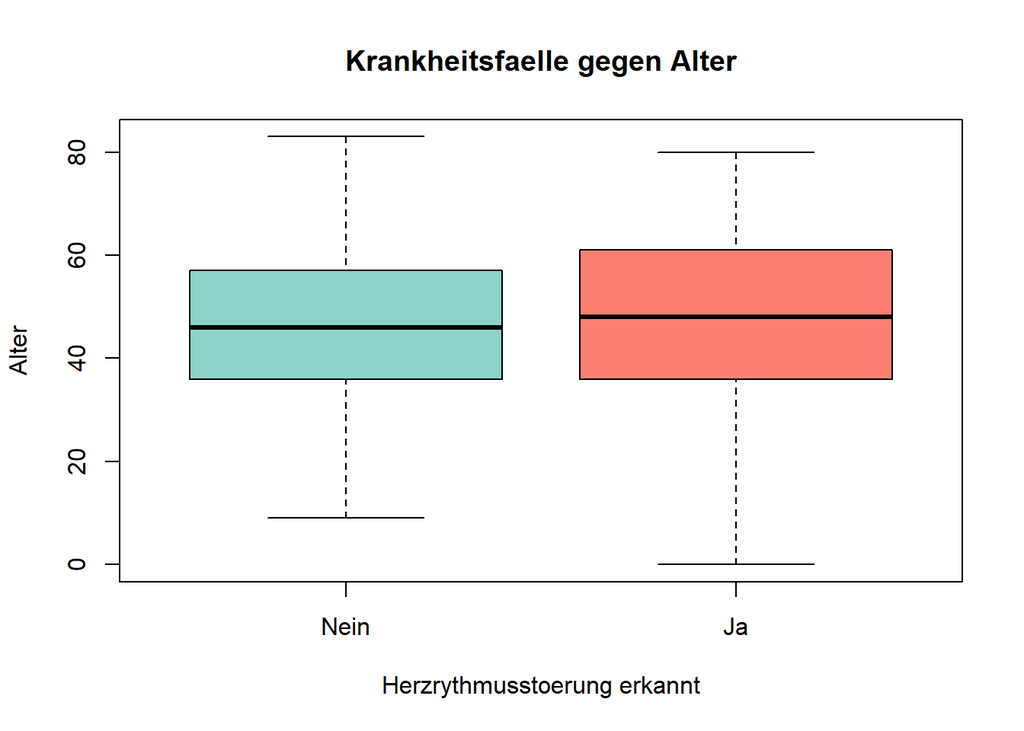

```r
## uebersetze kategorische Klassifizierungsspalte in Binaere (Krank/nicht krank) Spalte
temp <- as.numeric(arrhythmia$class)
isSick <- c()
for(i in 1:length(temp)){
  if(temp[i] > 1){
    isSick[i] <- 1
  }
  else{
    isSick[i] <- 0
  }
}
bmi <- arrhythmia$Weight/(arrhythmia$Height/100)^2

boxplot(arrhythmia$Age~isSick, names=c("Nein","Ja"), col=farben[c(1,4)],
        main="Krankheitsfaelle gegen Alter",
        xlab="Herzrythmusstoerung erkannt", ylab="Alter")
```

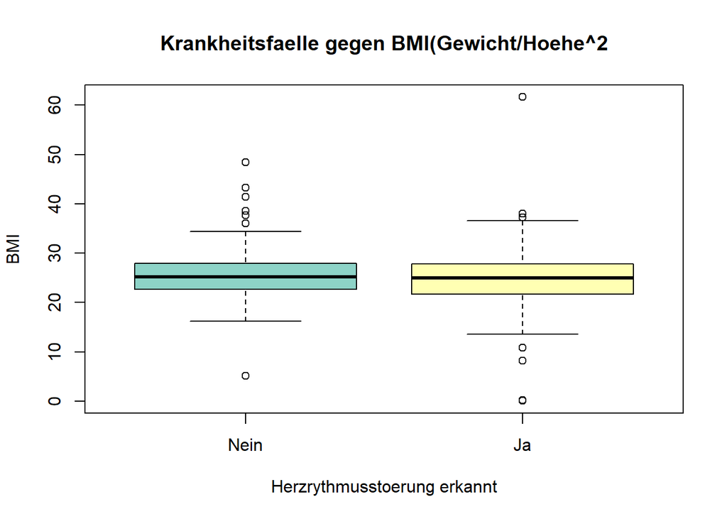

```r
boxplot(bmi~isSick, names=c("Nein","Ja"), col=farben[1:2],
        main="Krankheitsfaelle gegen BMI(Gewicht/Hoehe^2",
        xlab="Herzrythmusstoerung erkannt", ylab="BMI")
```

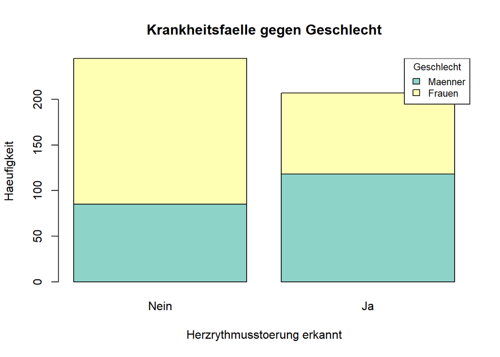

```r
barplot(table(arrhythmia$Sex,isSick),
        col=farben[1:2] ,main="Krankheitsfaelle gegen Geschlecht",names=c("Nein","Ja"),
        xlab="Herzrythmusstoerung erkannt", ylab="Haeufigkeit"); legend("topright",
                                                                        title="Geschlecht", c("Maenner","Frauen"),cex=0.8, fill = farben[1:2])
```

Aus den Plots fuer Krankheitsfaelle gegen Alter und Krankheitsfaelle gegen BMI kann man keine weiteren Schluesse ziehen, da die Boxplots bis auf ein paar Ausreisser sich geringfuegig voneinander unterscheiden.

Im Plot Krankhaltsfaelle gegen Geschlecht sieht man das Maenner marginal oefter an einer Herzrythmusstoerung leiden als Frauen. Ausserdem wird bei Frauen deutlich oefter negativ auf Herzrythmusstoerung getestet als Maenner.

# 4 Datenaufbereitung

## 4.1 Datenbereinigung

Da uns die missing Values bei der weiteren Bearbeitung der Daten stoeren, muessen wir sie vorher bearbeiten. Dazu pruefen wir zuerst wieviele Missing Values vorliegen und welche Merkmale am staerksen betroffen sind.

```r
## Missing Value Analyse
table(is.na(arrhythmia))
```

```
##
##  FALSE   TRUE
## 126152    408
```

```r
table(complete.cases(arrhythmia))
```

```
##
## FALSE  TRUE
##   384    68
```

```r
count.na <- function(x){sum(is.na(x))}

## J 376 Missing Values
## lösche J Auspraegung nach der Zusammenfassung um Verrueckung zu vermeiden
missing <- sapply(arrhythmia,count.na)
missing[missing>0]
```

```
##         T         P      QRST         J Heartrate
##         8        22         1       376         1
```

Die Analyse ergibt, dass ein Grossteil der fehlenden Werte in dem “J” Merkmal liegen. Aufgrund des hohen Anteils an Missing Eintraegen in dieser Spalte, entfernen wir sie aus dem Datensatz. Da der Anteil der fehlenden Werte in den restlichen Merkmale sehr gering ist, filtern wir diese aus.

```r
## lösche J Auspraegung am Ende der Datenaufbereitung um die Struktur des Datensatzes beizubehalten
arrhythmia$J <- rep(0,nrow(arrhythmia))

## loesche Zeilen mit NA
#arrhythmia <- na.omit(arrhythmia)
## dim(arrhythmia) 420 280
# na.approx(arrhythmia)
arrhythmia <- na.omit(arrhythmia)
```

## 4.2 Zusammenfassung der Kanaele

Um die Interpretationsfaehigkeit unseres Modells zu steigern fuehren wir eine Zusammenfassung der Kanaele durch.

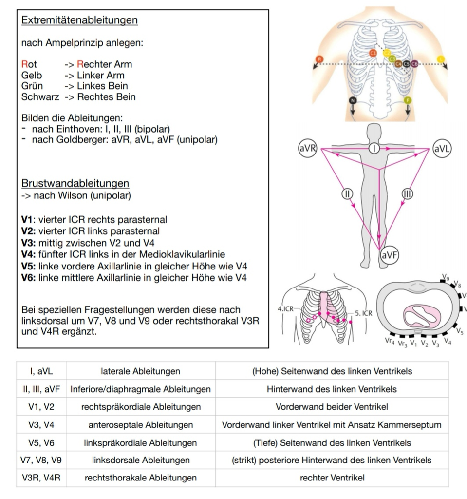

```r
knitr::include_graphics("Extremitaeten_Ableitunghen.jpeg")
```

Nach Absprache mit Fachexperten haben wir uns dazu entschieden, die Gruppierungen aus der Abbildung umzusetzen. Die Wellenbreiten werden durch das arithmetische Mittel zusammengefasst und bei den Amplituden nehmen wir den jeweils betragsmaessig groessten Wert mit Vorzeichen. Die Amplituden aendern das Vorzeichen abhaengig vom Kanal und vom Individuum, deshalb haben wir uns fuer diese Zusammenfassung entschieden Die binaeren Aussagen fassen wir ebenfalls zusammen. In der Praxis wird eine Aussage erst als wahr anerkannt, wenn sie von mindestens zwei Kanaelen bestaetigt wird.

```r
varName <- c("Qwidth","Rwidth","Swidth","R_width","S_width","nIntrinsDefl")

varName1 <- c("D1_aVL","D23_aVF","V1_V2","V3_V4","V5_V6","aVR")

varName2 <- c("JJamp","Qamp","Ramp","Samp","R_amp","S_amp","Pamp","Tamp","QRSAamp","QRSTAamp")

varName3 <- c("Rraggged","Rderiv","Praggged","Pderiv","Traggged","Tderiv")

## in der Praxis nimmt eine Aussage erst fuer wahr wenn sie von 2 Channel bestaetigt wird
evalTrue <- function(df){
  temp <-rowSums(as.matrix(df))
  vec <- c()
  for(i in 1:length(temp)){
    if(temp[i] >= 2){
      vec[i] <- 1
    }
    else{
      vec[i] <- 0
    }
  }
  return(vec)
}
## Zusammenfassung der fachlich zusammenhaengende Channels und Umbenennung der aVR bezogenen Zeiten
for(i in 1:10){
  if(i <= 6){
    ## Zusammenfassung der Wellenbreiten
    arrhythmia$x <-rowMeans(as.matrix(arrhythmia[c(15+i,63+i)]))
    names(arrhythmia)[names(arrhythmia) == "x"] <- paste0(varName1[1],".",varName[i],".mean")

    arrhythmia$x <-rowMeans(as.matrix(arrhythmia[c(27+i,39+i,75+i)]))
    names(arrhythmia)[names(arrhythmia) == "x"] <- paste0(varName1[2],".",varName[i],".mean")

    arrhythmia$x <-rowMeans(as.matrix(arrhythmia[c(87+i,99+i)]))
    names(arrhythmia)[names(arrhythmia) == "x"] <- paste0(varName1[3],".",varName[i],".mean")

    arrhythmia$x <-rowMeans(as.matrix(arrhythmia[c(111+i,123+i)]))
    names(arrhythmia)[names(arrhythmia) == "x"] <- paste0(varName1[4],".",varName[i],".mean")

    arrhythmia$x <-rowMeans(as.matrix(arrhythmia[c(135+i,147+i)]))
    names(arrhythmia)[names(arrhythmia) == "x"] <- paste0(varName1[5],".",varName[i],".mean")

    arrhythmia$x <-arrhythmia[,(51+i)]
    names(arrhythmia)[names(arrhythmia) == "x"] <- paste0(varName1[6],".",varName[i])
  }
  ## Zusammenfassung der Amplituden

  ## wir berechnen das betragsmässige Maximum fuer jede Gruppierung da die Amplituden abhaengig vom Kanal und Individuum neg bzw pos sein koennen

  arrhythmia$x <- arrhythmia[c(159+i,199+i)][cbind(1:nrow(arrhythmia), max.col(abs(arrhythmia[c(159+i,199+i)])))]
  names(arrhythmia)[names(arrhythmia) == "x"] <- paste0(varName1[1],".",varName2[i],".sigMax")

  arrhythmia$x <- arrhythmia[c(169+i,179+i,209+i)][cbind(1:nrow(arrhythmia), max.col(abs(arrhythmia[c(169+i,179+i,209+i)])))]
  names(arrhythmia)[names(arrhythmia) == "x"] <- paste0(varName1[2],".",varName2[i],".sigMax")

  arrhythmia$x <- arrhythmia[c(219+i,229+i)][cbind(1:nrow(arrhythmia), max.col(abs(arrhythmia[c(219+i,229+i)])))]
  names(arrhythmia)[names(arrhythmia) == "x"] <- paste0(varName1[3],".",varName2[i],".sigMax")

  arrhythmia$x <- arrhythmia[c(239+i,249+i)][cbind(1:nrow(arrhythmia), max.col(abs(arrhythmia[c(239+i,249+i)])))]
  names(arrhythmia)[names(arrhythmia) == "x"] <- paste0(varName1[4],".",varName2[i],".sigMax")

  arrhythmia$x <- arrhythmia[c(259+i,269+i)][cbind(1:nrow(arrhythmia), max.col(abs(arrhythmia[c(259+i,269+i)])))]
  names(arrhythmia)[names(arrhythmia) == "x"] <- paste0(varName1[5],".",varName2[i],".sigMax")

  arrhythmia$x <-arrhythmia[,(189+i)]
  names(arrhythmia)[names(arrhythmia) == "x"] <- paste0(varName1[6],".",varName2[i])
}
for(i in 1:6){
  ## Auswertung der binaeren Aussagen wird getrennt ausgefuehrt um sie leichter abtrennen zu koennen
  arrhythmia$x <- evalTrue(arrhythmia[seq(21+i,159,12)])
  names(arrhythmia)[names(arrhythmia) == "x"] <- paste0(varName3[i],".eval")
}

## loesche zusammengefasste Spalten und J Spalte
## dim(arrhythmia) 420 117
arrhythmia[,c(16:279)] <- NULL
arrhythmia$J <- NULL

psych::describe(arrhythmia)
```

|  | vars | n | mean | sd | median | trimmed | mad | min | max | range | skew | kurtosis | se |
| --- | --- | --- | --- | --- | --- | --- | --- | --- | --- | --- | --- | --- | --- |
| Age | 1 | 420 | 46.050000000 | 16.38716754 | 46.00000 | 46.583333333 | 16.30860 | 0.0 | 83.00000 | 83.00000 | -0.26732880 | -0.18776330 | 0.799611900 |
| Sex | 2 | 420 | 0.559523810 | 0.49703634 | 1.00000 | 0.574404762 | 0.00000 | 0.0 | 1.00000 | 1.00000 | -0.23894465 | -1.94752543 | 0.024252890 |
| Height | 3 | 420 | 166.159523810 | 38.49651479 | 164.00000 | 164.196428571 | 8.89560 | 105.0 | 780.00000 | 675.00000 | 13.20852091 | 192.29377764 | 1.878437580 |
| Weight | 4 | 420 | 67.657142857 | 16.63396679 | 68.00000 | 67.889880952 | 14.08470 | 6.0 | 176.00000 | 170.00000 | 0.18032073 | 5.18037565 | 0.811654470 |
| QRS_duration | 5 | 420 | 88.900000000 | 15.65177443 | 86.00000 | 86.937500000 | 10.37820 | 55.0 | 188.00000 | 133.00000 | 2.57599247 | 10.81893291 | 0.763728391 |
| P_R_interval | 6 | 420 | 158.935714286 | 36.61257085 | 157.00000 | 157.812500000 | 23.72160 | 0.0 | 524.00000 | 524.00000 | 2.03939976 | 27.50663400 | 1.786510528 |
| Q_T_interval | 7 | 420 | 367.559523810 | 33.12907828 | 367.50000 | 367.651785714 | 24.46290 | 232.0 | 509.00000 | 277.00000 | -0.30398163 | 2.73023730 | 1.616533496 |
| T_interval | 8 | 420 | 170.166666667 | 35.83788523 | 162.50000 | 164.803571429 | 21.49770 | 111.0 | 381.00000 | 270.00000 | 1.76896551 | 4.39809922 | 1.748709740 |
| P_interval | 9 | 420 | 91.876190476 | 21.82254106 | 91.00000 | 90.583333333 | 16.30860 | 0.0 | 205.00000 | 205.00000 | 1.21898638 | 5.49905564 | 1.064830970 |
| QRS | 10 | 420 | 33.273809524 | 46.09442192 | 40.00000 | 36.214285714 | 42.99540 | -172.0 | 169.00000 | 341.00000 | -0.81178438 | 1.85879987 | 2.249177486 |

[output cut: 107 more lines]

In der describe() Ausgabe kann man sehen, dass einige Merkmale konstant den selben Wert aufweisen. Das bedeutet diese Merkmale haben keinen Einfluss auf die Clusterung bzw. koennen zu singulaeren Matrizen fuehren und werden entfernt.

```r
## entferne Spalten mit Standardabweichung = 0
## dim(arrhythmia) 420  113
arrhythmia.omit <- arrhythmia[,apply(arrhythmia, 2, sd)==0]
arrhythmia <- arrhythmia[,apply(arrhythmia, 2, sd)>0]
psych::describe(arrhythmia.omit)
```

|  | vars | n | mean | sd | median | trimmed | mad | min | max | range | skew | kurtosis | se |
| --- | --- | --- | --- | --- | --- | --- | --- | --- | --- | --- | --- | --- | --- |
| D1_aVL.S_width.mean | 1 | 420 | 0 | 0 | 0 | 0 | 0 | 0 | 0 | 0 | NaN | NaN | 0 |
| V5_V6.S_width.mean | 2 | 420 | 0 | 0 | 0 | 0 | 0 | 0 | 0 | 0 | NaN | NaN | 0 |
| D1_aVL.S_amp.sigMax | 3 | 420 | 0 | 0 | 0 | 0 | 0 | 0 | 0 | 0 | NaN | NaN | 0 |
| V5_V6.S_amp.sigMax | 4 | 420 | 0 | 0 | 0 | 0 | 0 | 0 | 0 | 0 | NaN | NaN | 0 |

## 4.3 Untersuchung der univariaten Verteilungen

Bevor wir die Daten anfangen zu Clustern, ist es sinvoll die univariaten Verteilungen der Merkmale zu untersuchen. Zur Veranschaulichung folgen die Histogramme von 6 der 106 numerischen Merkmale.

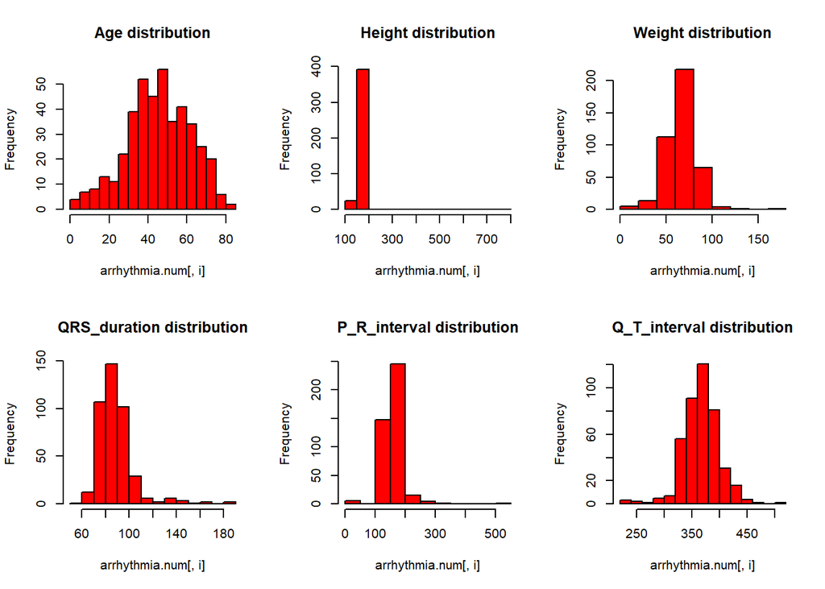

```r
par(mfrow = c(2, 3))

## Ausschluss der binaeren Werte da sie bei der Verteilungsuntersuchung anders behandelt werden muessen
arrhythmia.num <- arrhythmia[,c(1,3:(length(arrhythmia)-6))]
arrhythmia.bin <- arrhythmia[,-c(1,3:(length(arrhythmia)-6))]

## for(i in 1:ncol(arrhythmia.num)){
## Beschraenkung die ersten 6 Merkmale zur besseren uebersicht im Bericht
for(i in 1:6){
  col <- paste0(names(arrhythmia.num[i])," distribution")
  hist(arrhythmia.num[,i],breaks=12,col="red",main=col)
}
```

### 4.3.1 Ausreisser Behandlung

Im Histogramm “Height distribition” kann man zwei eindeutige Ausreisser erkennen. Dabei handelt es sich um 2 Patienten die groesser als 6 Meter sind. Solche Faelle wollen wir entfernen, da es sich eindeutig um falsche Daten handelt.

Der folgende Plot zeigt das Histogramm “Height distribition” ohne fehlerhafte Daten.

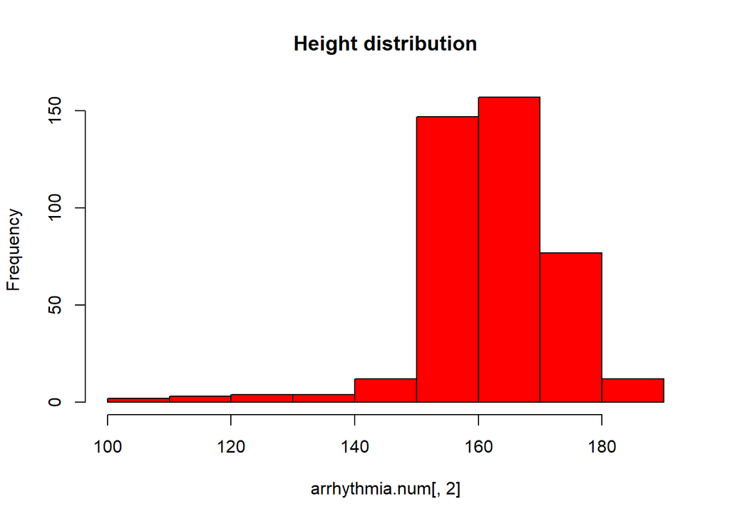

```r
arrhythmia.bin <- arrhythmia.bin[!(arrhythmia.num$Height>250),]
arrhythmia.num <- arrhythmia.num[!(arrhythmia.num$Height>250),]
col <- paste0(names(arrhythmia.num[2])," distribution")
hist(arrhythmia.num[,2],col="red",main=col)
```

Es ist moeglich das noch weitere solche Ausreisser im Datensatz liegen allerdings fehlt uns medizinisch technische Hintergrundwissen um diese korrekt zu erkennen.

### 4.3.2 Symmetrie Transformation

In den Histogrammen sind vermehrt rechts- und linksschiefe Verteilungen erkennbar. Unsere Methoden setzen zwar keine ideale Glockenkurvenfoermige Normalverteilung voraus, allerdings koennen schiefe Verteilungen in den einzelnen Merkmalen zu einer heterogenen Distanzmatrix fuehren, was die Differenzierbarkeit im Bereich niedriger Werte verschlechtert. Deshalb wenden wir eine Symmetrie Transformation auf alle Merkmale an, die eine schiefe Verteilung aufweisen.

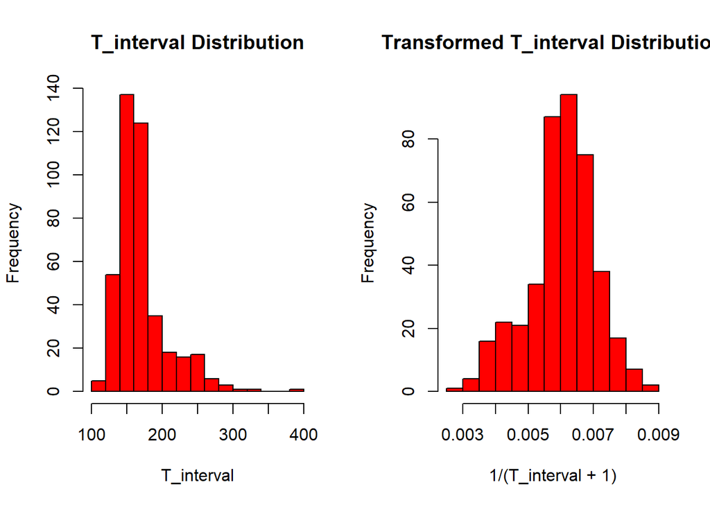

```r
par(mfrow = c(1, 2))
hist((arrhythmia.num$T_interval),breaks=12,col="red",main="T_interval Distribution", xlab="T_interval",ylab ="Frequency")
hist(1/(arrhythmia.num$T_interval + 1),breaks=12,col="red",main="Transformed T_interval Distribution", xlab="1/(T_interval + 1)",ylab ="Frequency")
```

Klassische Methoden zur Symmetrie Transformation sind zum Beispiel $\frac{1}{x}$, $x^2$ oder bei klinischen Daten oftmals verwendet $\log(x)$. Viele Transformation, besonders bei rechtsschiefen Verteilungen, setzen positive Werte voraus. Deshalb uebersetzen wir alle negativen Merkmale in unserem Datensatz in positive, mithilfe einer einfachen linear Verschiebung.

```r
is.negative <- function(vec){
  for(i in vec){
    if(i < 0){
      return(TRUE)
    }
  }
  return(FALSE)
}
linScalePos <- function(df){
  for(i in 1:length(df)){
    if(is.negative(df[,i])){
      df[,i] <- df[,i]- min(df[,i])
    }
  }
  return(df)
}
arrhythmia.num <- linScalePos(arrhythmia.num)
```

Um die Verzerrung der Verteilung auszulesen kann man Woelbungs- und Schiefeparameter berechnen. Hier nutzen wir aber nur unser grobes Augenmass, was fuer die begrenzte Anzahl an Merkmalen genuegt. Je nach Grad der Schiefe wenden wir folgende Transformationen an. Rechtsschiefe Merkmale: $\sqrt{x}$, $log(x+1)$, $\frac{1}{x + 1}$ Linksschiefe Merkmale: $x^2$, $x^3$

Wir addieren eine eins hinzu, um Division, sowie Logarithmierung mit 0 Werten zu vermeiden.

```r
arrhythmia.num$QRS_duration <- log10(arrhythmia.num$QRS_duration+1)
arrhythmia.num$P_R_interval <- sqrt(arrhythmia.num$P_R_interval)
arrhythmia.num$T_interval <- (1/(arrhythmia.num$T_interval + 1))
arrhythmia.num$QRS <- (arrhythmia.num$QRS)^2
arrhythmia.num$P <- (arrhythmia.num$P)^2
arrhythmia.num$D1_aVL.Qwidth.mean <- log10(arrhythmia.num$D1_aVL.Qwidth.mean +1 )
arrhythmia.num$D23_aVF.Qwidth.mean <- log10(arrhythmia.num$D23_aVF.Qwidth.mean +1)
arrhythmia.num$aVR.Qwidth <- log(arrhythmia.num$aVR.Qwidth+1)
arrhythmia.num$D1_aVL.Swidth.mean <- sqrt(arrhythmia.num$D1_aVL.Swidth.mean)
arrhythmia.num$V5_V6.Swidth.mean <- sqrt(arrhythmia.num$V5_V6.Swidth.mean)
arrhythmia.num$D1_aVL.Ramp.sigMax <- sqrt(arrhythmia.num$D1_aVL.Ramp.sigMax)
arrhythmia.num$D23_aVF.Ramp.sigMax <- sqrt(arrhythmia.num$D23_aVF.Ramp.sigMax)
arrhythmia.num$V1_V2.Ramp.sigMax <- log10(arrhythmia.num$V1_V2.Ramp.sigMax+1)
arrhythmia.num$V3_V4.Ramp.sigMax <- sqrt(arrhythmia.num$V3_V4.Ramp.sigMax)
arrhythmia.num$D1_aVL.Samp.sigMax <- (arrhythmia.num$D1_aVL.Samp.sigMax)^3
arrhythmia.num$D23_aVF.Samp.sigMax <- (arrhythmia.num$D23_aVF.Samp.sigMax)^3
arrhythmia.num$V1_V2.Samp.sigMax <- (arrhythmia.num$V1_V2.Samp.sigMax)^2
arrhythmia.num$V3_V4.Samp.sigMax <- (arrhythmia.num$V3_V4.Samp.sigMax)^3
arrhythmia.num$V5_V6.Samp.sigMax <- (arrhythmia.num$V5_V6.Samp.sigMax)^3
arrhythmia.num$D1_aVL.nIntrinsDefl.mean <- sqrt(arrhythmia.num$D1_aVL.nIntrinsDefl.mean)
arrhythmia.num$V1_V2.nIntrinsDefl.mean <- log(arrhythmia.num$V1_V2.nIntrinsDefl.mean+1)
arrhythmia.num$D23_aVF.QRSAamp.sigMax <- (arrhythmia.num$D23_aVF.QRSAamp.sigMax)^2
arrhythmia.num$aVR.QRSAamp <- (arrhythmia.num$aVR.QRSAamp)^2
arrhythmia.num$D1_aVL.Tamp.sigMax <- (arrhythmia.num$D1_aVL.Tamp.sigMax)^2
arrhythmia.num$aVR.QRSAamp <- (arrhythmia.num$aVR.QRSAamp)^2
arrhythmia.num$V1_V2.QRSTAamp.sigMax <- sqrt(arrhythmia.num$V1_V2.QRSTAamp.sigMax)
arrhythmia.num$aVR.QRSTAamp <- (arrhythmia.num$aVR.QRSTAamp)^2
```

## 4.4 Standardisierung

Da unsere Merkmale von sehr verschiedener Natur sind, wie Gewicht, Hoehe, Alter, Millivolt und Millisekunden, halten wir es fuer sinnvoll eine standardisierung unserer Merkmale durchzufuehren. D.h. bei jedem Merkmal wird der Mittelwert auf 0 und die Standardabweichung auf 1 gesetzt.

$Z=\frac{X - \mu}{\sigma}$

```r
trueclus <- arrhythmia.num$class
arrhythmia.num$class <- NULL
arrhythmia.num <-scale(arrhythmia.num)
arrhythmia.num <- as.data.frame(arrhythmia.num)

arrhythmia <- cbind(arrhythmia.num,arrhythmia.bin)
```

# 5 Hauptkomponentenanalyse

Mit der Hauptkomponentanalyse werden Lineakombinationen unserer Merkmale bestimmt, die einen moeglichst grossen Anteil der Varianz innerhalb des Datensatzes erklaeren. Zur Bestimmung der Anzahl der Hauptkomponenten betrachten wir zunaechst ein Scree Plot der die Groesse der Eigenwerte gegen die dazugehoerigen Hauptkomponenten darstellt.

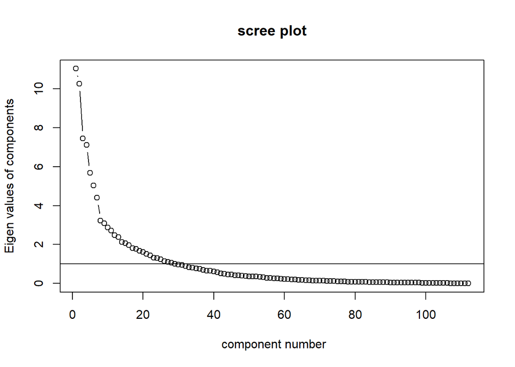

```r
PCarrhythmia <- prcomp(arrhythmia)
EVarrhythmia <- eigen(cor(arrhythmia))
VSS.scree(arrhythmia)
```

Ein gaengiges Kriterium ist eine Mindestvarianz der Hauptkomponenten von 1. Damit wuerden wir hier schon bis zu 30 Komponenten waehlen. Nach dem Scree Elbow Kriterium koennten wir uns auch nach den einzelnen Knicken orientieren. Demnach waeren 13 Komponenten moeglich. Oftmals werden auch soviele Komponenten genommen wie benoetigt werden, um mindestens 80 % der Gesamtvarianz zu erklaeren. Fuer einen besseren Ueberblick untersuchen wir zunaechst die ersten 30 Hauptkomponenten.

```r
unrot30 <- principal(arrhythmia,30,rotate="none")
unrot30
```

```
## Principal Components Analysis
## Call: principal(r = arrhythmia, nfactors = 30, rotate = "none")
## Standardized loadings (pattern matrix) based upon correlation matrix
##                             PC1   PC2   PC3   PC4   PC5   PC6   PC7   PC8   PC9
## Age                       -0.34  0.27  0.04  0.01 -0.22 -0.20 -0.01  0.17  0.03
## Height                    -0.09  0.17 -0.04  0.14 -0.26  0.20  0.00  0.17  0.12
## Weight                    -0.16  0.20  0.05  0.17 -0.24  0.01 -0.03  0.13  0.22
## QRS_duration              -0.18  0.07  0.03  0.63  0.47  0.13 -0.03  0.07  0.04
## P_R_interval              -0.03 -0.03 -0.09  0.06 -0.01  0.06 -0.01  0.06  0.22
## Q_T_interval              -0.01  0.34  0.06  0.08  0.14  0.11  0.01  0.15 -0.12
## T_interval                 0.16 -0.17  0.03 -0.31 -0.23 -0.20 -0.09  0.05 -0.19
## P_interval                -0.08 -0.02 -0.07  0.14  0.01  0.05 -0.01  0.02  0.28
## QRS                        0.56 -0.13 -0.54 -0.02  0.25 -0.28 -0.05 -0.05 -0.03
## T                         -0.04 -0.03  0.02  0.06  0.03  0.20 -0.07 -0.27 -0.14
## P                          0.09 -0.15 -0.24  0.00  0.04  0.00 -0.15  0.09  0.13
## QRST                       0.50 -0.21 -0.54 -0.02  0.21 -0.06 -0.09 -0.19 -0.22
## Heartrate                 -0.15 -0.32 -0.08  0.12  0.05 -0.16 -0.03 -0.19  0.23
## D1_aVL.Qwidth.mean        -0.07 -0.09 -0.09  0.08  0.00  0.33  0.39 -0.09 -0.40
## D23_aVF.Qwidth.mean        0.13 -0.11 -0.03  0.31 -0.38 -0.23 -0.12  0.16  0.33
## V1_V2.Qwidth.mean         -0.59  0.18 -0.43 -0.17  0.18 -0.01  0.20  0.25  0.12
## V3_V4.Qwidth.mean         -0.37 -0.09 -0.45  0.01 -0.17  0.13  0.43 -0.21  0.05
## V5_V6.Qwidth.mean          0.11 -0.18 -0.40  0.47 -0.27  0.09  0.29 -0.11 -0.02
## aVR.Qwidth                -0.12  0.23  0.22 -0.63  0.47 -0.09 -0.23 -0.16  0.15
## D1_aVL.JJamp.sigMax        0.29 -0.48 -0.27 -0.33 -0.06  0.14  0.03  0.25  0.13
## D23_aVF.JJamp.sigMax      -0.21 -0.03  0.29  0.04  0.03  0.25 -0.08 -0.25  0.12
## V1_V2.JJamp.sigMax        -0.15  0.64 -0.17  0.30  0.25  0.18 -0.04 -0.17  0.14
## V3_V4.JJamp.sigMax        -0.17  0.25 -0.46  0.14  0.41  0.42 -0.07  0.00  0.22
## V5_V6.JJamp.sigMax         0.00 -0.51 -0.13 -0.26 -0.12  0.42 -0.05 -0.14  0.12
## aVR.JJamp                 -0.20  0.55  0.12  0.34  0.06 -0.28  0.04 -0.06 -0.18
## D1_aVL.Rwidth.mean        -0.38  0.58  0.40  0.12  0.09  0.11  0.11  0.01  0.14
## D23_aVF.Rwidth.mean        0.44  0.28 -0.44  0.03  0.35 -0.19  0.01 -0.01 -0.03
## V1_V2.Rwidth.mean          0.42 -0.29  0.40  0.35 -0.06  0.05 -0.09  0.08  0.07
## V3_V4.Rwidth.mean          0.60  0.11  0.53  0.14  0.04 -0.09 -0.01  0.21 -0.01
## V5_V6.Rwidth.mean          0.01  0.74  0.10  0.11  0.30 -0.15  0.07  0.12  0.06
## aVR.Rwidth                -0.23 -0.60  0.14  0.17  0.21  0.23  0.00  0.13  0.08
## D1_aVL.Qamp.sigMax         0.05  0.07  0.32  0.00 -0.10 -0.25 -0.24  0.06  0.33
## D23_aVF.Qamp.sigMax        0.15  0.02 -0.17 -0.22  0.33  0.23  0.04 -0.07 -0.34
## V1_V2.Qamp.sigMax          0.50 -0.26  0.45  0.15 -0.22  0.03 -0.20 -0.18 -0.11
## V3_V4.Qamp.sigMax          0.40  0.09  0.47  0.04  0.13 -0.10 -0.40  0.23 -0.06
## V5_V6.Qamp.sigMax          0.05  0.22  0.38 -0.40  0.22 -0.15 -0.22  0.25  0.05
```

[output cut: 427 more lines]

```
## Cumulative Proportion 0.70 0.73 0.75 0.77 0.80 0.82 0.83 0.85 0.87 0.89 0.90
##                       PC23 PC24 PC25 PC26 PC27 PC28 PC29 PC30
## SS loadings           1.33 1.30 1.25 1.14 1.11 1.06 1.00 0.96
## Proportion Var        0.01 0.01 0.01 0.01 0.01 0.01 0.01 0.01
## Cumulative Var        0.76 0.77 0.78 0.79 0.80 0.81 0.82 0.83
## Proportion Explained  0.01 0.01 0.01 0.01 0.01 0.01 0.01 0.01
## Cumulative Proportion 0.92 0.93 0.94 0.96 0.97 0.98 0.99 1.00
##
## Mean item complexity =  7.1
## Test of the hypothesis that 30 components are sufficient.
##
## The root mean square of the residuals (RMSR) is  0.02
##  with the empirical chi square  2137.81  with prob <  1
##
## Fit based upon off diagonal values = 0.99
```

Die ersten 13 Hauptkomponenten erklaeren 61% Gesamtvarianz, was in der Regel zu gering ist. Der Eigenwert der 29. Hauptkomponente ist 1.004722 und der Eigenwert der 30. Hauptkomponente ist 0.959373. Das heisst wir koennten 29 waehlen, um eine Mindestvarianz der Eigenwerte von 1 zu erfuellen. Um 80% der kumulierten Gesamtvarianz erklaeren zu koennen benoetigen wir mindestens 27 Hauptkomponenten.

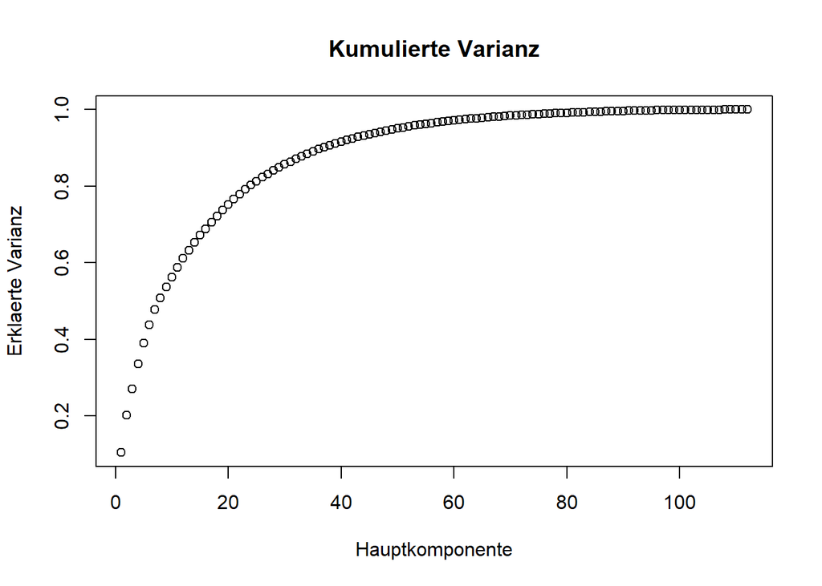

```r
cumprob <- cumsum(PCarrhythmia$sdev^2 / sum(PCarrhythmia$sdev^2))
plot(cumprob[0:112], xlab = "Hauptkomponente", ylab = "Erklaerte Varianz",
     main = "Kumulierte Varianz")
```

Da wir fuer 80% erklaerte Varianz 27 Komponenten benoetigen, betrachten wir nur die ersten 9 die benoetigt werden um 50% der Varianz zu erklaeren. Fuer 80% der Varianz benoetigen wir 27 Hauptkomponenten. Um eine bessere Interpretierbarkeit zu erreichen. Tolerieren wir eine Reduktion auf 50% erklaerte Varianz, da dafuer nur 9 Hauptkomponenten benoetigt werden.

Es ist ausserdem sinnvoll die ersten beiden Hauptkomponenten genauer zu untersuchen, da diese mit 19% bereits einen relativ grossen Teil der Varianz unseres Datensatzes erklaeren.

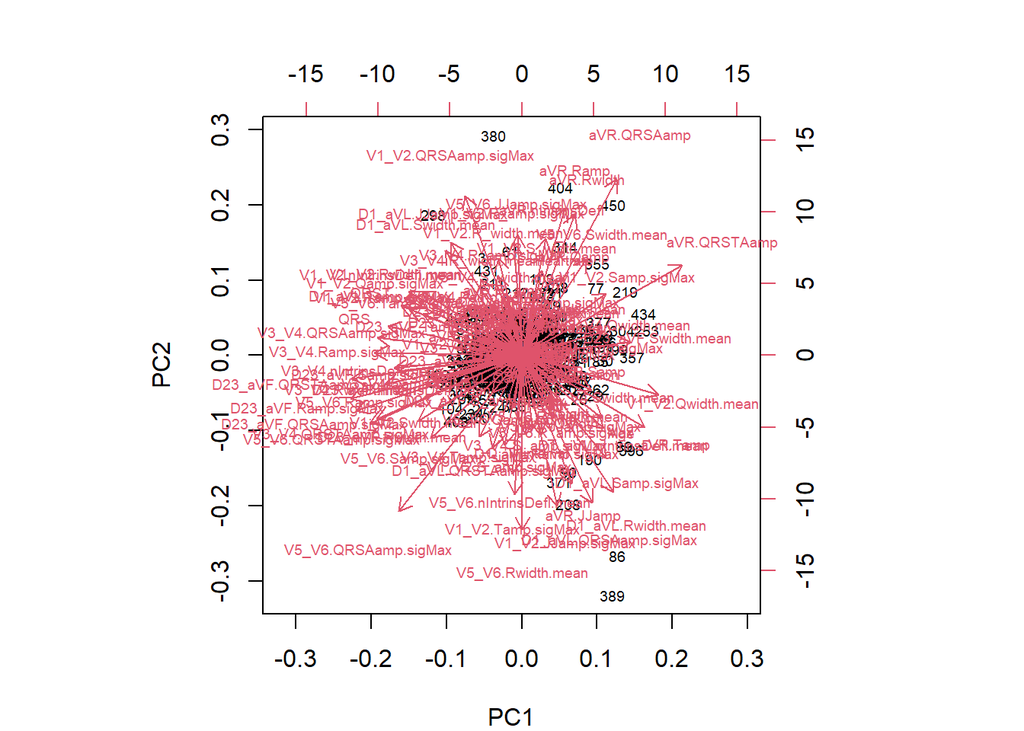

```r
par(mar=c(4,4,4,4))
biplot(PCarrhythmia, cex=0.6, xpd=NA, pch=1)
```

Der Biplot beschreibt die Ladungen der ersten beiden Hauptkomponenten und plottet die Patienten als Punkte auf das orthoganlen Koordinatensystem das daraus gebildet wird.

Interpretation folgt: Aus dem Biplot geht hervor, das die Merkmale bezueglich des Anteils an den zwei ersten Hauptkomponenten keine ersichtbare Tendenz haben.

Da die erklaerten Varianzen pro Merkmal in vielen der Hauptkomponenten enthalten sind, fuehren wir zusaetzlich eine Rotation der Hauptkomponenten um die Interpretierbarkeit zu erhoehen.

```r
rot2 <- principal(arrhythmia, nfactors=2,rotate="varimax")
```

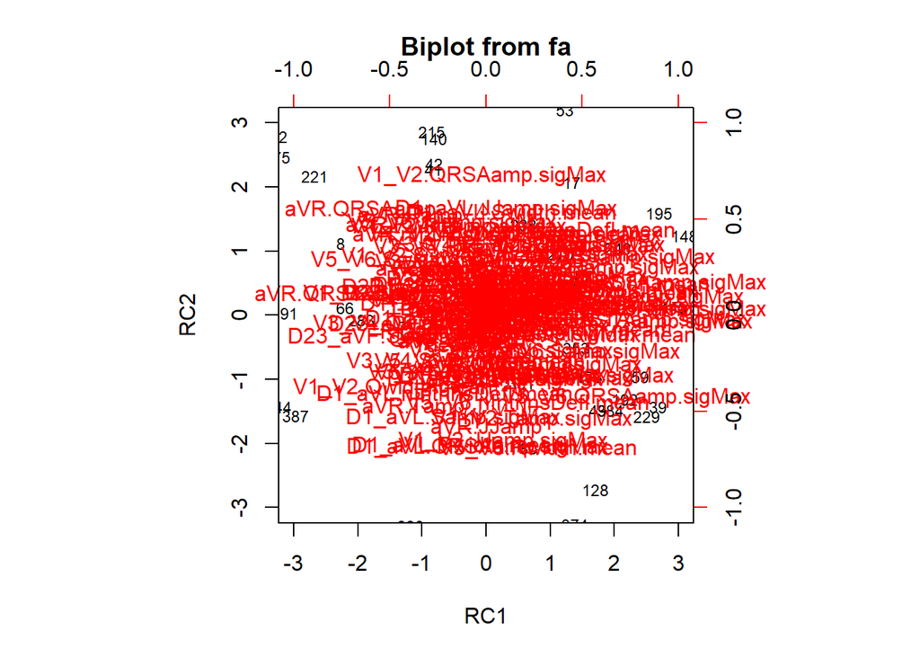

```r
biplot(rot2, labels=rownames(arrhythmia), cex=0.6, xpd=NA, pch=1)
```

Varimax ist ein orthogonales Roationsverfahren bei dem die Basis rotiert wird. Das Verfahren maximiert die Summe der Varianzen der quadrierten Ladungen und bewahrt dabei die Orthogonalitaet. Ist die Varianz der Ladungen einer Hauptkomponente nahe 0, so wird diese noch weiter reduziert. Liegen sehr hohe Varianz der Ladungen vor, wird diese verstaerkt.

# 6 Clusteranalyse

In diesen Abschnitt fuehren wir eine hierarchische Clusteranalyse durch und diskutieren die Ergebnisse.

## 6.1 Bestimmung der Distanzmatrix

Zur Ausfuehrung der Clusteranalyse benoetigen wir zunaechst eine Distanzmatrix. Da in unseren Datensatz gemischte Datentypen (binaer und numerisch), liegen, ,utzen wir die Gower Distanz, die binaere Werte beruecksichtigt und somit eine repraesentative Distanzmatrix erzeugt.

```r
dd <- daisy(arrhythmia,metric="gower")
```

## 6.2 Auswahl des Fusionsalgorithmus

Als naechstes fuehren wir eine hierarchische Clusteranalyse mit verschiedenen Fusionsalgorithmen durch, um die geeignetste Methode zu bestimmen.

```r
hier.ave <- hclust(dd, method="average")
cor_cophenetic(hier.ave, dd)
```

```
## [1] 0.8278062
```

```r
hier.complete <- hclust(dd, method="complete")
cor_cophenetic(hier.complete, dd)
```

```
## [1] 0.351363
```

```r
hier.wardD2 <- hclust(dd, method="ward.D2")
cor_cophenetic(hier.wardD2, dd)
```

```
## [1] 0.3763963
```

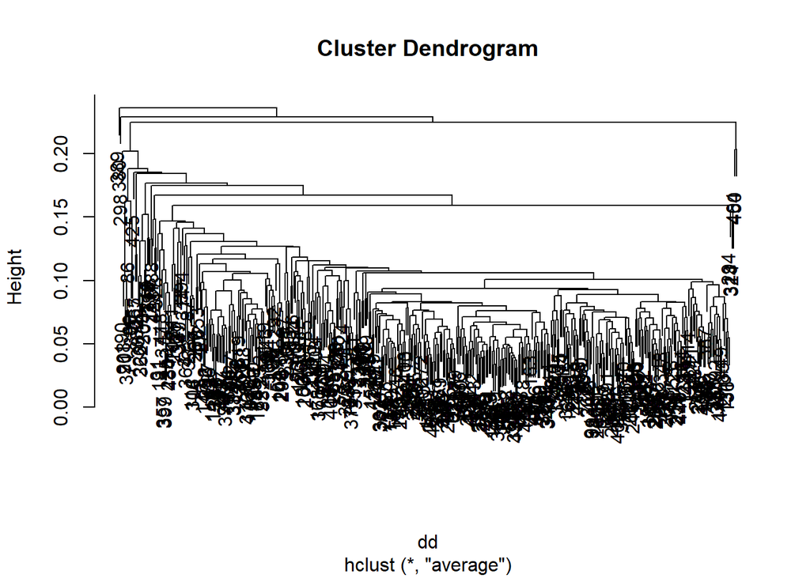

```r
plot(hier.ave)
```

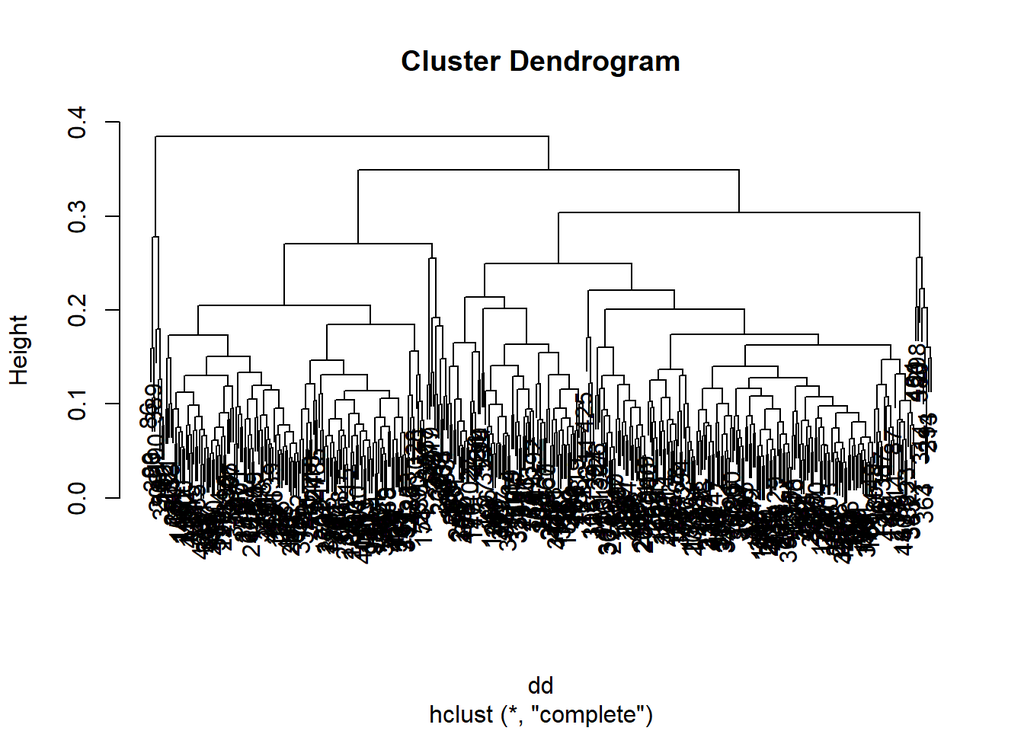

```r
plot(hier.complete)
```

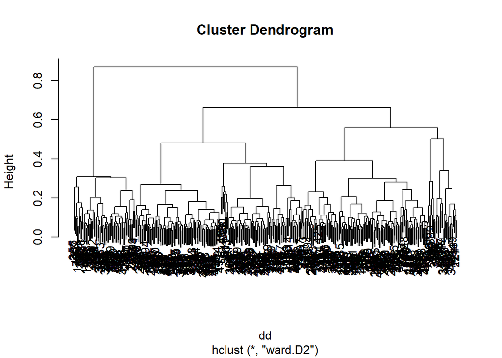

```r
plot(hier.wardD2)
```